# Script2_Averaging_Replicates

Manon Morin

6/29/2020

## **STEP 2 :Gene fitness calculation: averaging across replicates**

## Script: Script2_Averaging_Replicates.Rmd

That second part of the analysis averages gene fitness across replicates. If all studied conditions have the same T0 sample, it requires for each replicate the .RData files generated in the first part of the analysis “Script1_GeneFitness_Replicate.Rmd”. If studied conditions have a different T0 sample, it requires the output of the script Multiple_T0s.R Before averaging replicates, we perform a quick analysis of correlation between replicates of the same condition. It produces a final file containing final normalized gene fitness and associated fitness variance across replicates. Plots are generated during data processing to visually follow data transformation.

### Example description

This run illustrates the second step of RB-TnSeq analysis to identify interaction fitness. This is the run for averaging fitness values for all the replicates of the 5 conditions RB-TnSeq example.

### Run

#### Packages and functions

```r
rm(list=ls())

library(dplyr)
```

```r
library(ggplot2)
library(ggrepel)
library(DescTools)
library(gridExtra)
source("Correlation_Rep.R")
source("Weighted_average.R")
```

#### Data upload and parameters set up

```r
# Step1: Parameters set up and Data import
 # Import .Rdata files generated for each replicate in Script1_GeneFitness_Replicate.Rmd
 # Isolate and rename All_data_Replicate just after loading to avoid overwritting.
 # Note: if conditions have different T0s and have been processed independently in "Gene_Fitness_Replicate.R", Step 1 is replaced by running the script: "Multiple_T0s.R"


  # Parameter set up
org_locId="Num"   # "Num" if numeric , "Char" if characters
multiT=FALSE  # Switch to TRUE if you used different T0s for a set of conditions and have to run Multiple_T0 to generate the table containing all replicates.

if (multiT==FALSE){
  load("Ex_Run_R1.Rdata") #load the .Rdata file from Gene_Fitness_Replicate.R for replicate 1
  Replicate1=All_data_Replicate

  load("Ex_Run_R2.Rdata") #load the .Rdata file from Gene_Fitness_Replicate.R for replicate 2
  Replicate2=All_data_Replicate

  load("Ex_Run_R3.Rdata") #load the .Rdata file from Gene_Fitness_Replicate.R for replicate 3
  Replicate3=All_data_Replicate

  # We bind all replicates together and add a column "Rep" to identify were it is coming from

  Replicate1$Rep="R1"
  Replicate2$Rep="R2"
  Replicate3$Rep="R3"

  AllReplicate=rbind(Replicate1,Replicate2,Replicate3)
  head(AllReplicate, n=5)
}
```

```
##   locusId sysName begin scaffold        Cdt NormFitness Fitness_Variance Rep
## 1   14146   b0001   190     7023 Condition1 -0.10763776      0.004234506  R1
## 2   14147   b0002   337     7023 Condition1 -0.39564492      0.158219137  R1
## 3   14148   b0003  2801     7023 Condition1 -0.60484100      0.198116180  R1
## 4   14149   b0004  3734     7023 Condition1 -1.37486386      0.416450536  R1
## 5   14150   b0005  5234     7023 Condition1  0.06967739      0.054488610  R1
```

```r
if (multiT==TRUE){
  load(".Rdata")    #Generated in Multiple_T0s.R
  genes.tab <- readr::read_delim("genes.GC.txt",
                               "\t", escape_double = FALSE, trim_ws = TRUE)  # import your gene.GC file
}
```

#### Side de by side Replicate visualization

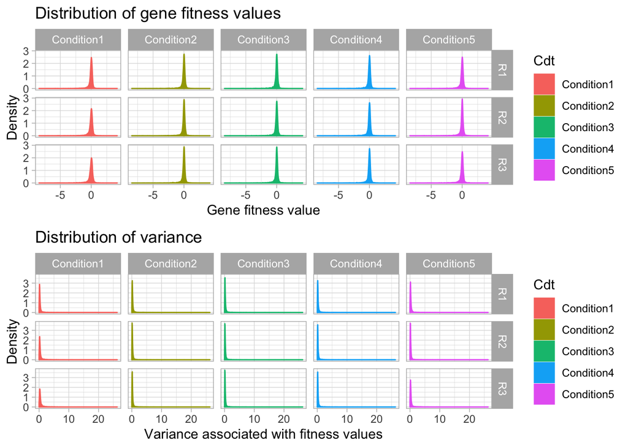

```r
# Step 2: Replicates visualization

  # Plots for fitness values or variance distribution in each condition and replicate
plot1_fit=ggplot(AllReplicate, aes(x=NormFitness,col=Cdt))+geom_density(aes(fill=Cdt)) + theme_light()+
  ggtitle("Distribution of gene fitness values") + facet_grid(Rep ~ Cdt) + labs(x = "Gene fitness value", y="Density")

plot1_var=ggplot(AllReplicate, aes(x=Fitness_Variance,col=Cdt))+geom_density(aes(fill=Cdt)) + theme_light()+
  ggtitle("Distribution of variance") + facet_grid(Rep ~ Cdt) + labs(x = "Variance associated with fitness values", y="Density")

grid.arrange(plot1_fit, plot1_var, ncol=1)
```

#### Replicates correlation analysis

*Note for this example: while the script generates plots for each correlation analysis (Pearson, Spearman and Lin), here we only display the plot for the Pearson correlation*

```r
# Step 3: Replicate correlation calculation and visualization (for gene fitness values)
  # Determines the correlation between each replicate, stores them in a matrix
  # Visualizes correlation in two different ways: (i)  usual correlation plots and (ii) distribution of correlation across all conditions and replicates

  # Calculation of correlation for all pairs of replicate (and each condition) + plots
Correlation_table_fit=Correlation_Rep(AllReplicate) # Calculates different correlation coefficient + save plots
Correlation_table_fit
```

```
## # A tibble: 15 x 5
##    Cond       Comp     P_Rsquared S_Rsquared L_Rsquared
##    <chr>      <chr>         <dbl>      <dbl>      <dbl>
##  1 Condition1 R2 vs R1      0.798      0.591      0.797
##  2 Condition1 R3 vs R1      0.768      0.572      0.763
##  3 Condition1 R3 vs R2      0.764      0.553      0.762
##  4 Condition2 R2 vs R1      0.866      0.696      0.865
##  5 Condition2 R3 vs R1      0.883      0.689      0.881
##  6 Condition2 R3 vs R2      0.873      0.711      0.873
##  7 Condition3 R2 vs R1      0.879      0.704      0.878
##  8 Condition3 R3 vs R1      0.882      0.703      0.881
##  9 Condition3 R3 vs R2      0.894      0.725      0.894
## 10 Condition4 R2 vs R1      0.836      0.669      0.835
## 11 Condition4 R3 vs R1      0.865      0.667      0.865
## 12 Condition4 R3 vs R2      0.846      0.687      0.845
## 13 Condition5 R2 vs R1      0.883      0.704      0.883
## 14 Condition5 R3 vs R1      0.837      0.652      0.836
## 15 Condition5 R3 vs R2      0.868      0.676      0.864
```

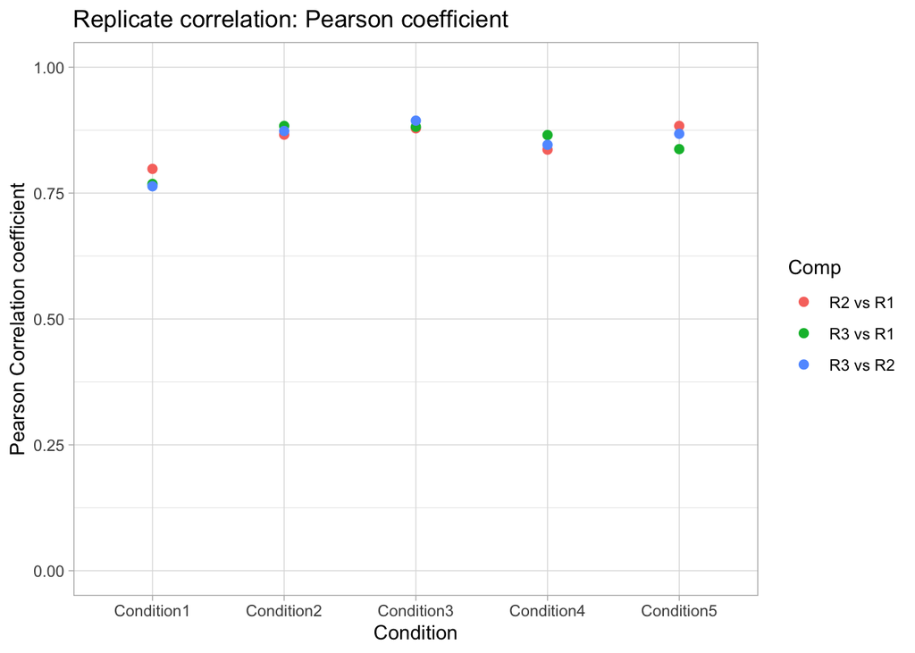

```r
plot_allPcor_fit=ggplot(Correlation_table_fit, aes(x=Cond,y=P_Rsquared)) + geom_point(size=2, aes(col=Comp))+
  theme_light() + labs(y = "Pearson Correlation coefficient", x="Condition") + ylim(0,1) +  ggtitle("Replicate correlation: Pearson coefficient")

plot_allScor_fit=ggplot(Correlation_table_fit, aes(x=Cond,y=P_Rsquared)) + geom_point(size=2, aes(col=Comp))+
  theme_light() + labs(y = "Spearman Correlation coefficient", x="Condition") + ylim(0,1) + ggtitle("Replicate correlation: Spearman coefficient")

plot_allLcor_fit=ggplot(Correlation_table_fit, aes(x=Cond,y=P_Rsquared)) + geom_point(size=2, aes(col=Comp))+
  theme_light() + labs(y = "Lin's Correlation coefficient", x="Condition") + ylim(0,1) + ggtitle("Replicate correlation: Lin coefficient")

grid.arrange(plot_allPcor_fit, nrow=1)
```

#### Averaging replicates

Gene fitness values are averaged across replicates using the inverse-variance weighted average. Associated squared standard error (var) and associated standard deviations are also calculated.  
*Note for this example: while the script generates plots for the average gene fitness, a plot for gene fitness variance and a plot for gene fitness standard deviation, here we only display the plot for the average fitness*

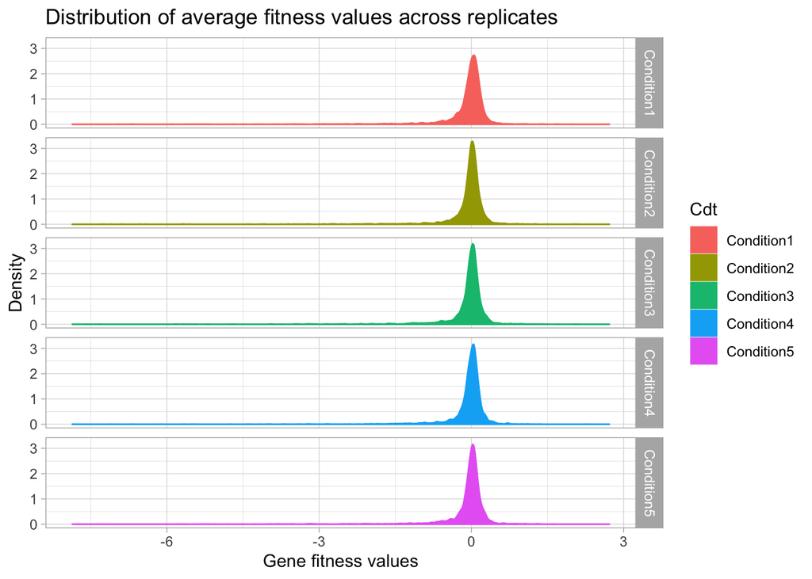

```r
# Step 4: Weighted average of gene fitness across replicate
 # Averages gene fitness values across replicates for each condition
 # Visualizes fitness values distrbutions, squared standard error (var) ditributions and standard deviation distributions

Average_fitness=Weighted_average(AllReplicate, org_locId)

plot2_fit=ggplot(Average_fitness, aes(x=WeightedFit,col=Cdt))+geom_density(aes(fill=Cdt)) + theme_light()+
  ggtitle("Distribution of average fitness values across replicates") + facet_grid(Cdt ~ .) + labs(x = "Gene fitness values", y="Density")

plot2_var=ggplot(Average_fitness, aes(x=WeightedVar,col=Cdt))+geom_density(aes(fill=Cdt)) + theme_light()+
  ggtitle("Distribution of squared standard error") + facet_grid(Cdt ~ .) + labs(x = "Squared standard error associated with fitness values", y="Density")

plot2_sd=ggplot(Average_fitness, aes(x=Weightedsdev,col=Cdt))+geom_density(aes(fill=Cdt)) + theme_light()+
  ggtitle("Distribution of standard deviation") + facet_grid(Cdt ~ .) + labs(x = "Standard deviation associated with fitness values", y="Density")

grid.arrange(plot2_fit, ncol=1)
```

#### Saving data

```r
# Step5: Saving data
if(org_locId=="Num"){
  Final_gene_Fitness=left_join(genes.tab,Average_fitness, by=c("locusId")) %>% select(-c(type,strand,GC,nTA))
  Final_gene_Fitness=na.omit(Final_gene_Fitness)
}

if(org_locId=="Char"){
  Average_fitness$locusId=as.character(Average_fitness$locusId)  # the locusId in the Mean table are factors, we need to turn then into charcater for the left_join
  Final_gene_Fitness=left_join(genes.tab,Average_fitness, by=c("locusId")) %>% select(-c(type,strand,GC,nTA))
  Final_gene_Fitness$name="No_name"   #replace the NA by something else, otherwise the next NAomit removes everything
  Final_gene_Fitness=na.omit(Final_gene_Fitness)
}

write.csv(Final_gene_Fitness,"All_Fitness_Values_Exemple.csv")

save(Final_gene_Fitness, Average_fitness, genes.tab,
     Correlation_table_fit,AllReplicate, file="All_Fitness_Values_Exemple.RData")
```